# Team: Bruna Medeiros, Mahima Masetty, Anusha Bhat, Aarav Dewangam

```python
# import libraries
import pandas as pd
import numpy as np
from sklearn.metrics import rand_score
from sklearn.cluster import KMeans
from sklearn.model_selection import train_test_split
from sklearn.preprocessing import MinMaxScaler
import matplotlib.pyplot as plt
from sklearn.metrics import silhouette_score
from sklearn.metrics import pairwise_distances

np.random.seed(42)
```

```python
# read data
df = pd.read_excel('Boats.xlsx')
df
```

|  | RESPID | Q1.1 | Q1.2 | Q1.3 | Q1.4 | Q1.5 | Q1.6 | Q1.7 | Q1.8 | Q1.9 | ... | Q16.20 | Q16.21 | Q16.22 | Q16.23 | Q16.24 | Q16.25 | Q16.26 | Q16.27 | Q17 | Q18 |
| --- | --- | --- | --- | --- | --- | --- | --- | --- | --- | --- | --- | --- | --- | --- | --- | --- | --- | --- | --- | --- | --- |
| 0 | 23822 | 5 | 1 | 5 | 5 | 5 | 5 | 5 | 3 | 5 | ... | 4 | 4 | 4 | 4 | 5 | 4 | 4 | 4 | 0 | 1 |
| 1 | 224795 | 3 | 2 | 4 | 4 | 4 | 4 | 5 | 3 | 4 | ... | 4 | 3 | 3 | 4 | 3 | 3 | 3 | 3 | 1 | 1 |
| 2 | 20952 | 3 | 1 | 4 | 4 | 5 | 4 | 4 | 2 | 4 | ... | 5 | 3 | 3 | 5 | 2 | 4 | 3 | 5 | 1 | 0 |
| 3 | 5612 | 5 | 2 | 3 | 4 | 5 | 5 | 3 | 3 | 3 | ... | 4 | 4 | 4 | 4 | 2 | 5 | 5 | 4 | 1 | 0 |
| 4 | 15016 | 4 | 2 | 4 | 5 | 5 | 4 | 5 | 4 | 5 | ... | 4 | 4 | 5 | 5 | 3 | 4 | 5 | 4 | 0 | 0 |
| ... | ... | ... | ... | ... | ... | ... | ... | ... | ... | ... | ... | ... | ... | ... | ... | ... | ... | ... | ... | ... | ... |
| 2808 | 485225 | 5 | 1 | 5 | 5 | 5 | 5 | 5 | 2 | 3 | ... | 5 | 5 | 3 | 4 | 4 | 3 | 4 | 4 | 0 | 0 |
| 2809 | 484245 | 2 | 1 | 2 | 1 | 1 | 1 | 2 | 1 | 1 | ... | 3 | 4 | 3 | 3 | 4 | 2 | 4 | 4 | 0 | 0 |
| 2810 | 224990 | 3 | 3 | 4 | 4 | 3 | 3 | 4 | 3 | 4 | ... | 3 | 4 | 3 | 3 | 2 | 3 | 3 | 3 | 0 | 0 |
| 2811 | 17590 | 4 | 2 | 4 | 4 | 4 | 3 | 3 | 4 | 2 | ... | 4 | 4 | 4 | 3 | 3 | 3 | 3 | 2 | 0 | 0 |
| 2812 | 8241 | 5 | 5 | 2 | 2 | 1 | 2 | 3 | 5 | 1 | ... | 4 | 2 | 4 | 4 | 2 | 2 | 1 | 2 | 0 | 0 |

2813 rows × 82 columns

```python
df.columns
```

```
Index(['RESPID', 'Q1.1', 'Q1.2', 'Q1.3', 'Q1.4', 'Q1.5', 'Q1.6', 'Q1.7',
       'Q1.8', 'Q1.9', 'Q1.10', 'Q1.11', 'Q1.12', 'Q1.13', 'Q1.14', 'Q1.15',
       'Q1.16', 'Q1.17', 'Q1.18', 'Q1.19', 'Q1.20', 'Q1.21', 'Q1.22', 'Q1.23',
       'Q1.24', 'Q1.25', 'Q1.26', 'Q1.27', 'Q1.28', 'Q1.29', 'Q2',
       'Q2.Cluster', 'Q3', 'Q4', 'Q5', 'Q6', 'Q7.1', 'Q7.2', 'Q7.3', 'Q7.4',
       'Q8', 'Q9.1', 'Q9.2', 'Q9.3', 'Q9.4', 'Q9.5', 'Q10', 'Q11', 'Q12',
       'Q13', 'Q14', 'Q15', 'Q16', 'Q16.1', 'Q16.2', 'Q16.3', 'Q16.4', 'Q16.5',
       'Q16.6', 'Q16.7', 'Q16.8', 'Q16.9', 'Q16.10', 'Q16.11', 'Q16.12',
       'Q16.13', 'Q16.14', 'Q16.15', 'Q16.16', 'Q16.17', 'Q16.18', 'Q16.19',
       'Q16.20', 'Q16.21', 'Q16.22', 'Q16.23', 'Q16.24', 'Q16.25', 'Q16.26',
       'Q16.27', 'Q17', 'Q18'],
      dtype='object')
```

# Question 1:

```python
df = df.iloc[:, 1:30]
df
```

|  | Q1.1 | Q1.2 | Q1.3 | Q1.4 | Q1.5 | Q1.6 | Q1.7 | Q1.8 | Q1.9 | Q1.10 | ... | Q1.20 | Q1.21 | Q1.22 | Q1.23 | Q1.24 | Q1.25 | Q1.26 | Q1.27 | Q1.28 | Q1.29 |
| --- | --- | --- | --- | --- | --- | --- | --- | --- | --- | --- | --- | --- | --- | --- | --- | --- | --- | --- | --- | --- | --- |
| 0 | 5 | 1 | 5 | 5 | 5 | 5 | 5 | 3 | 5 | 4 | ... | 4 | 5 | 5 | 5 | 5 | 5 | 5 | 3 | 4 | 5 |
| 1 | 3 | 2 | 4 | 4 | 4 | 4 | 5 | 3 | 4 | 4 | ... | 3 | 4 | 4 | 3 | 4 | 4 | 4 | 4 | 4 | 4 |
| 2 | 3 | 1 | 4 | 4 | 5 | 4 | 4 | 2 | 4 | 3 | ... | 3 | 3 | 5 | 4 | 4 | 4 | 5 | 3 | 3 | 4 |
| 3 | 5 | 2 | 3 | 4 | 5 | 5 | 3 | 3 | 3 | 4 | ... | 3 | 5 | 4 | 5 | 3 | 5 | 4 | 3 | 3 | 5 |
| 4 | 4 | 2 | 4 | 5 | 5 | 4 | 5 | 4 | 5 | 4 | ... | 4 | 4 | 4 | 5 | 4 | 4 | 5 | 4 | 4 | 4 |
| ... | ... | ... | ... | ... | ... | ... | ... | ... | ... | ... | ... | ... | ... | ... | ... | ... | ... | ... | ... | ... | ... |
| 2808 | 5 | 1 | 5 | 5 | 5 | 5 | 5 | 2 | 3 | 2 | ... | 2 | 5 | 5 | 4 | 4 | 5 | 4 | 4 | 4 | 2 |
| 2809 | 2 | 1 | 2 | 1 | 1 | 1 | 2 | 1 | 1 | 2 | ... | 1 | 1 | 3 | 1 | 1 | 1 | 1 | 1 | 1 | 1 |
| 2810 | 3 | 3 | 4 | 4 | 3 | 3 | 4 | 3 | 4 | 3 | ... | 3 | 4 | 3 | 3 | 3 | 3 | 3 | 3 | 4 | 4 |
| 2811 | 4 | 2 | 4 | 4 | 4 | 3 | 3 | 4 | 2 | 3 | ... | 2 | 3 | 4 | 4 | 4 | 4 | 2 | 4 | 3 | 2 |
| 2812 | 5 | 5 | 2 | 2 | 1 | 2 | 3 | 5 | 1 | 5 | ... | 3 | 3 | 3 | 2 | 2 | 2 | 3 | 4 | 3 | 5 |

2813 rows × 29 columns

```python
# checking for missing values
print("Missing Values:")
print(df.isnull().sum())
```

```
Missing Values:
Q1.1     0
Q1.2     0
Q1.3     0
Q1.4     0
Q1.5     0
Q1.6     0
Q1.7     0
Q1.8     0
Q1.9     0
Q1.10    0
Q1.11    0
Q1.12    0
Q1.13    0
Q1.14    0
Q1.15    0
Q1.16    0
Q1.17    0
Q1.18    0
Q1.19    0
Q1.20    0
Q1.21    0
Q1.22    0
Q1.23    0
Q1.24    0
Q1.25    0
Q1.26    0
Q1.27    0
Q1.28    0
Q1.29    0
dtype: int64
```

```python
# summary stats to understand data
print("Descriptive Summary Statistics:")
print(df.describe(include='all'))
```

```
Descriptive Summary Statistics:
              Q1.1         Q1.2         Q1.3         Q1.4         Q1.5  \
count  2813.000000  2813.000000  2813.000000  2813.000000  2813.000000
mean      4.028084     2.886242     3.115535     3.890508     3.552435
std       0.819565     1.013704     1.021019     0.819889     0.927591
min       1.000000     1.000000     1.000000     1.000000     1.000000
25%       4.000000     2.000000     2.000000     3.000000     3.000000
50%       4.000000     3.000000     3.000000     4.000000     4.000000
75%       5.000000     4.000000     4.000000     4.000000     4.000000
max       5.000000     5.000000     5.000000     5.000000     5.000000

              Q1.6         Q1.7         Q1.8         Q1.9        Q1.10  ...  \
count  2813.000000  2813.000000  2813.000000  2813.000000  2813.000000  ...
mean      3.954497     3.674369     3.737291     2.886242     3.366868  ...
std       0.824193     0.897230     0.816538     1.076319     0.931775  ...
min       1.000000     1.000000     1.000000     1.000000     1.000000  ...
25%       4.000000     3.000000     3.000000     2.000000     3.000000  ...
50%       4.000000     4.000000     4.000000     3.000000     3.000000  ...
75%       4.000000     4.000000     4.000000     4.000000     4.000000  ...
max       5.000000     5.000000     5.000000     5.000000     5.000000  ...

             Q1.20        Q1.21        Q1.22        Q1.23        Q1.24  \
count  2813.000000  2813.000000  2813.000000  2813.000000  2813.000000
mean      3.157483     4.249556     4.009243     3.563455     4.108781
std       0.969161     0.727144     0.739016     1.023536     0.758244
min       1.000000     1.000000     1.000000     1.000000     1.000000
25%       2.000000     4.000000     4.000000     3.000000     4.000000
50%       3.000000     4.000000     4.000000     4.000000     4.000000
75%       4.000000     5.000000     4.000000     4.000000     5.000000
max       5.000000     5.000000     5.000000     5.000000     5.000000

             Q1.25        Q1.26        Q1.27        Q1.28        Q1.29
count  2813.000000  2813.000000  2813.000000  2813.000000  2813.000000
mean      3.790970     2.946676     3.156061     3.308923     4.030217
std       0.912434     1.050300     1.049027     0.982519     0.730953
min       1.000000     1.000000     1.000000     1.000000     1.000000
25%       3.000000     2.000000     2.000000     3.000000     4.000000
50%       4.000000     3.000000     3.000000     3.000000     4.000000
75%       4.000000     4.000000     4.000000     4.000000     4.000000
max       5.000000     5.000000     5.000000     5.000000     5.000000

[8 rows x 29 columns]
```

## Split our data into train and test sets:

```python
train_df, test_df = train_test_split(df, test_size=0.2, random_state=42)

print(train_df.head())
print(test_df.head())
```

```
      Q1.1  Q1.2  Q1.3  Q1.4  Q1.5  Q1.6  Q1.7  Q1.8  Q1.9  Q1.10  ...  Q1.20  \
1742     4     3     2     3     3     4     3     4     2      4  ...      2
2184     2     3     3     5     4     2     2     4     2      3  ...      2
1566     4     2     4     4     4     5     5     5     4      3  ...      4
2512     4     5     1     1     1     2     4     5     1      2  ...      1
1025     5     2     5     5     4     5     5     5     5      3  ...      4

      Q1.21  Q1.22  Q1.23  Q1.24  Q1.25  Q1.26  Q1.27  Q1.28  Q1.29
1742      4      3      1      3      4      2      3      2      4
2184      3      4      4      3      3      3      2      3      4
1566      5      5      5      5      5      3      3      4      5
2512      4      3      1      1      4      1      1      1      5
1025      5      4      4      5      4      4      3      4      4

[5 rows x 29 columns]
      Q1.1  Q1.2  Q1.3  Q1.4  Q1.5  Q1.6  Q1.7  Q1.8  Q1.9  Q1.10  ...  Q1.20  \
450      4     4     4     4     3     5     5     5     4      4  ...      3
1174     3     3     3     3     2     4     3     3     3      4  ...      3
1192     4     2     3     4     3     4     4     4     2      4  ...      2
2423     3     3     3     4     4     4     3     4     1      2  ...      4
1641     3     2     3     4     4     3     3     4     3      4  ...      3

      Q1.21  Q1.22  Q1.23  Q1.24  Q1.25  Q1.26  Q1.27  Q1.28  Q1.29
450       4      4      4      5      5      4      3      3      4
1174      5      4      2      4      4      3      2      4      3
1192      4      4      3      4      4      3      2      3      3
2423      5      4      5      3      4      2      2      2      4
1641      5      4      3      4      4      3      2      4      3

[5 rows x 29 columns]
```

## Perform clustering:

```python
# define kmodes function --> from lecture notes

def kmodes(X, n_clusters, max_iter=1000,random_state=42):
    # Initialize the centroids randomly
    initial_centroids_idx = np.random.choice(range(X.shape[0]), size=n_clusters, replace=False)
    centroids = X.iloc[initial_centroids_idx].to_numpy()

    for _ in range(max_iter):
        # Compute distances between data points and centroids
        distances = np.zeros((X.shape[0], n_clusters))
        for i in range(n_clusters):
            distances[:, i] = np.sum(X != centroids[i], axis=1)

        # Assign data points to the nearest centroid
        labels = np.argmin(distances, axis=1)

        # Update centroids based on the assigned data points
        for i in range(n_clusters):
            # Calculate the centroid for cluster i
            cluster_points = X.iloc[labels == i].to_numpy()

            if cluster_points.shape[0] > 0:  # Ensure cluster is not empty
              centroid = np.array([
                  np.argmax(np.bincount(cluster_points[:, j])) for j in range(cluster_points.shape[1])])

            else: # Handle empty cluster (e.g., reassign centroid randomly or use fallback)
              centroid = np.zeros(X.shape[1], dtype=int)

            centroids[i] = centroid # Update the centroids array

    return labels, centroids
```

```python
# function to find the optimal number of clusters
def elbow_silhouette(X, max_k):
    inertia = []
    silhouette_scores = []
    for k in range(1, max_k + 1):
        #labels, _ = kmodes(X, n_clusters=k)
        labels, centroids = kmodes(X, n_clusters=k)
        # Compute the cost (inertia) for the current k
        # Using elblow method
        distances = np.zeros((X.shape[0], k))
        for i in range(k):
          distances[:, i] = np.sum(X != centroids[i], axis=1)
          # distances[:, i] = np.sum(X != X.iloc[labels == i].mode().iloc[0], axis=1)

        inertia.append(np.sum(np.min(distances, axis=1)))  # Total cost

        if k >= 2: # Calculating silhouette scores
          # Compute pairwise Hamming distances
          distance_matrix = pairwise_distances(X, metric="hamming")
          silhouette_avg = silhouette_score(distance_matrix, labels, metric="precomputed")
          silhouette_scores.append(silhouette_avg)

    # Plot elbow plot
    plt.figure(figsize=(10, 6))
    plt.plot(range(1, max_k + 1), inertia, marker='o')
    plt.title('Elbow Method')
    plt.xlabel('Number of clusters (k)')
    plt.ylabel('Inertia (Cost)')
    plt.xticks(range(1, max_k + 1))
    plt.grid()
    plt.show()

    # Plot silhouette score
    plt.figure(figsize=(10, 6))
    plt.plot(range(2, max_k + 1), silhouette_scores, marker='o')
    plt.title('Silhouette Score Method')
    plt.xlabel('Number of clusters (k)')
    plt.ylabel('Silhouette Score')
    plt.xticks(range(2, max_k + 1))
    plt.grid()
    plt.show()
```

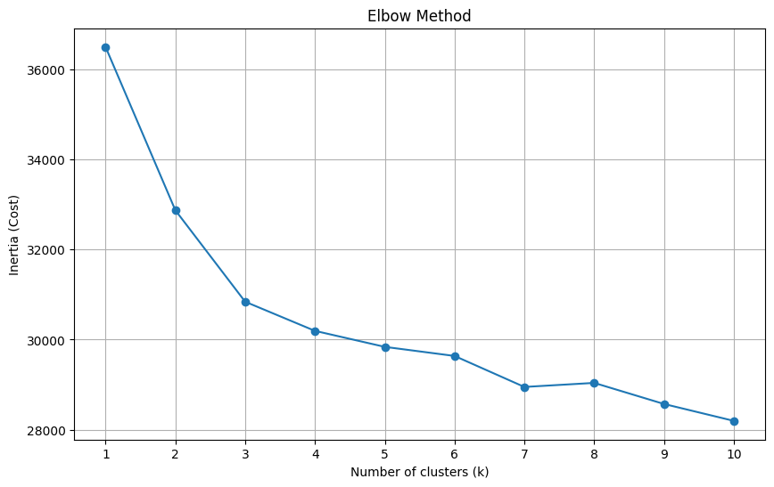

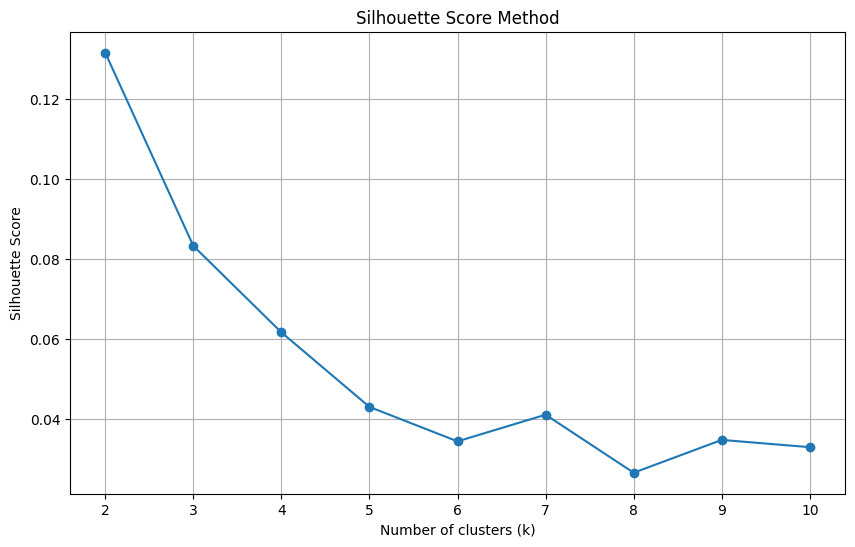

```python
max_k = 10
elbow_silhouette(train_df, max_k)
```

## k=3

According to our Elbow Method plot, we agreed that having 3 and 4 clusters were both optimal choices. However, looking at the silhouette score, k=3 has a higher silhouette score.

```python
# Perform K-modes clustering
k = 3  # Number of clusters
labels, centroids = kmodes(train_df, n_clusters=k, random_state=42)
```

```python
# Print cluster assignments and centroids
print("Cluster Assignments:")
print(labels)

# Rename columns
row_names = ["Shop around",
                "Low price > brand",
                "Brand is my identity",
                "Brand reputation",
                "High quality premium",
                "Boat for Self reward",
                "Boat for Achievement",
                "Functionality",
                "Status symbol",
                "Receive expert opinion",
                "Self/minor repairs",
                "Basic boat preference",
                "Latest/greatest boat preference",
                "Latest/greatest accessory preference",
                "Technology",
                "Give advice",
                "Knowledgeable",
                "Boat for adventure",
                "Boat for nature",
                "Enjoys boat related activities",
                "Boat for relaxation",
                "Boat for staying active",
                "Boat for sports",
                "Boat for socializing",
                "Being in charge",
                "Powerful boat",
                "Boat as favorite hobby",
                "Passion for boats",
                "Boat amongst other hobbies"
                ]

centroids_transposed = centroids.T
centroids_df = pd.DataFrame(centroids_transposed, index=row_names)

# Rename cluster columns to more descriptive names
centroids_df.columns = ["Premium Enthusiast", "Pragmatic Boater", "Quality Seeker"]

# Add formatting for better readability
def format_dataframe(df):
    # Style the DataFrame for display
    styled_df = df.style.format(precision=0)  # No decimals for integers
    styled_df = styled_df.set_table_attributes('style="width:100%; border-collapse:collapse;"')  # Adjust width
    styled_df = styled_df.set_caption("Cluster Profiles")  # Add a caption

    return styled_df

# Format the DataFrame
formatted_centroids = format_dataframe(centroids_df)

# Display the styled DataFrame
formatted_centroids
```

```
Cluster Assignments:
[1 2 0 ... 0 2 2]
```

Cluster Profiles

|  | Premium Enthusiast | Pragmatic Boater | Quality Seeker |
| --- | --- | --- | --- |
| Shop around | 5 | 4 | 4 |
| Low price > brand | 2 | 2 | 3 |
| Brand is my identity | 4 | 2 | 3 |
| Brand reputation | 4 | 4 | 4 |
| High quality premium | 4 | 4 | 3 |
| Boat for Self reward | 5 | 4 | 4 |
| Boat for Achievement | 4 | 4 | 4 |
| Functionality | 4 | 4 | 4 |
| Status symbol | 4 | 2 | 3 |
| Receive expert opinion | 4 | 4 | 3 |
| Self/minor repairs | 4 | 4 | 4 |
| Basic boat preference | 2 | 2 | 3 |
| Latest/greatest boat preference | 4 | 2 | 3 |
| Latest/greatest accessory preference | 4 | 3 | 3 |
| Technology | 4 | 4 | 4 |
| Give advice | 4 | 2 | 3 |
| Knowledgeable | 4 | 3 | 3 |
| Boat for adventure | 5 | 4 | 4 |
| Boat for nature | 5 | 4 | 4 |
| Enjoys boat related activities | 4 | 2 | 3 |
| Boat for relaxation | 5 | 4 | 4 |
| Boat for staying active | 5 | 4 | 4 |
| Boat for sports | 5 | 4 | 4 |
| Boat for socializing | 5 | 4 | 4 |
| Being in charge | 5 | 4 | 4 |
| Powerful boat | 4 | 2 | 3 |
| Boat as favorite hobby | 4 | 2 | 3 |
| Passion for boats | 4 | 3 | 3 |
| Boat amongst other hobbies | 5 | 4 | 4 |

## Testing

```python
# define kmodes function --> from lecture notes
def test_kmodes(X, centroids, n_clusters, random_state=42):
  silhouette_scores = []

  # Compute distances between data points and centroids
  distances = np.zeros((X.shape[0], n_clusters))
  for i in range(n_clusters):
    distances[:, i] = np.sum(X != centroids[i], axis=1)

    # Assign data points to the nearest centroid
    labels = np.argmin(distances, axis=1)

  distance_matrix = pairwise_distances(X, metric="hamming")
  silhouette_avg = silhouette_score(distance_matrix, labels, metric="precomputed")
  silhouette_scores.append(silhouette_avg)

  return labels, silhouette_scores
```

```python
labels_test, silhouette_test = test_kmodes(test_df, centroids, 3, random_state=42)
print("Test Silhouette Score:",silhouette_test)
```

```
Test Silhouette Score: [0.07720854703664402]
```

The test silhouette score is close to the training's score.

# Question 2

**Segment I: Premium Enthusiasts**

**Target Persona:**

Premium Enthusiasts are adventure-driven and prioritize self-reward, relaxation, and socializing through boating. They strongly favor high-quality, premium boats and value their boating experiences as a primary hobby. They are not quite price-sensitive and seek powerful, feature-rich boats that support their active and adventurous lifestyles.

**4 Ps of Marketing:**

*Product:*

- Offer luxury boats with cutting-edge technology, premium materials, and customizable options.
- Include features like advanced navigation systems, high-speed engines, comfortable seating, and ample space for socializing.
- Provide exclusive adventure packages, such as guided trips or premium marina memberships.

*Price:*

- Use a premium pricing strategy to emphasize exclusivity and quality.
- Offer tiered pricing with customizable add-ons for personalization.
- Provide financing options to make high-end purchases more accessible.

*Place:*

- Sell through high-end dealerships and exclusive marinas.
- Ensure participation in boat shows that include experiential showrooms where customers can test boats in premium settings (e.g., lakes or coastal regions).
- Partner with luxury resorts to showcase the boats in action.

*Promotion:*

- Focus on emotional advertising highlighting adventure, self-reward, relaxation, and a genuine love for boats.
- Leverage digital campaigns showcasing the boats' advanced feat.
- Host exclusive events, such as luxury boat expos or adventure-themed gatherings.

\

**Segment II: Pragmatic Boaters**

**Target Persona:**

Pragmatic Boaters are practical and balanced, valuing functionality and quality without prioritizing brand identity or exclusivity. They are moderately price-sensitive and look for boats that provide solid value, reliability, and seek expert opinion on all things boats. Boating is part of their lifestyle but not a core passion.

**4 Ps of Marketing:**

*Product:*

- Focus on versatile, functional boats designed for leisure and utility.
- Ensure durability and ease of maintenance.
- Include basic essential features like dependable engines, basic technology, and comfortable seating.

*Price:*

- Use a value-based pricing strategy, balancing affordability with quality.
- Offer discounts or promotions for trade-ins and package deals (e.g., boat + accessories).
- Provide transparent pricing to build trust.

*Place:*

- Sell through well-known, accessible dealerships and online platforms.
- Partner with general sporting goods stores for boating accessories.
- Provide mobile service options for easy maintenance.

*Promotion:*

- Highlight the boats' reliability, value, and low maintenance in advertising.
- Leverage expert endorsements and how-to content.
- Run promotions such as seasonal discounts or loyalty rewards.

\

**Segment III: Quality Seekers**

**4 Ps of Marketing:**

*Product:*

- Offer mid-to-high-quality boats with a focus on durability, safety, and comfort.
- Include clean, elegant designs and dependable technology without overcomplicating functionality.
- Provide accessories that enhance utility and ease of use.

*Price:*

- Use a mid-to-premium pricing strategy to reflect quality.
- Offer value-added packages such as extended warranties or free maintenance.
- Provide attractive trade-in programs for upgrading to newer models

*Place:*

- Sell through trusted, well-established dealerships with a reputation for quality service and participate in boat shows.
- Create an online store featuring detailed product descriptions, customer reviews, and a configurator tool.
- Build partnerships with reputable marinas and boating clubs.

*Promotion:*

- Emphasize reliability, quality, and the long-term value of the boats.
- Use targeted advertising in specialized magazines and online platforms for boating enthusiasts.
- Offer demo days and workshops to showcase the boats’ features and reliability.

```python
# Count the number of customers in each cluster
label_series = pd.Series(labels)
cluster_counts = label_series.value_counts()

# Calculate percentages
cluster_percentages = (cluster_counts / len(labels)) * 100

# Create a summary DataFrame
cluster_summary = pd.DataFrame({
    "Cluster": cluster_counts.index,
    "Count": cluster_counts.values,
    "Percentage": cluster_percentages.values
})
cluster_summary
```

|  | Cluster | Count | Percentage |
| --- | --- | --- | --- |
| 0 | 2 | 879 | 39.066667 |
| 1 | 0 | 694 | 30.844444 |
| 2 | 1 | 677 | 30.088889 |

# Question 3

## What questions should we add?

To enhance our dataset and improve our clustering, we can ask the questions below. They are designed to be in the same scale as the current subset of questions (Q1.1-1.29) used in our original clustering to ensure consistency. These questions will give us more insight into the financial backgrounds of our customers and their preferred types of boats. In our original clustering, the clusters mainly differed on these two aspects, therefore, we will include more questions to further differentiate our customers which in turn dictate our marketing efforts and business decisions.

**Using the scale provided, please indicate how much you agree or disagree with each statement:**

1: Strongly Disagree | 2: Disagree | 3: Neither Agree nor disagree | 4: Agree | 5: Strongly Agree

- The boat's resale value is important to me
- I am open to purchasing a new boat rather than a used boat
- I am interested in eco-friendly or sustainable boats
- I plan on joining boating communities or clubs
- I prefer purchasing a boat with cash
- I prefer to rent a boat
- I prefer a small boat (fits 1-6 people)
- I prefer a medium-sized boat (fits 7-12 people)
- I prefer a larger boat (fits 13+ people)

# Question 4

## Weighting Strategy:

Our attributes questionnaire (Q1.1-Q1.29), gave us important insights in terms of our client's preferences and what kind of boaters they are. This allows us to appropriately adjust our marketing strategy to advertise the most appropriate boat and experience for our customer which, in return, improves our sales.

However, we find important to emphasize the questions that give us clear and actionable insights to improve other steps of the sale journey: supply allocation, product offering and pricing strategy. Improving operations and financial performance are the most factors for improving our bottom line.

As a result, we can put more emphasis on questions relating to customers' price sensititivity and questions that provide insights into what boat features are most important to them. This will allow us to tailor our product offering more accordingly. We can apply these weights when calculating the distance/dissimilarity score when assigning data points to clusters. The different weigths will give the features listed below more importance when calculating the distance and determining the clusters.

**Everything will be weighted equally, besides the following questions:**

*Low price > brand: 4*

*Brand reputation: 2*

*High quality premium: 4*

*Functionality: 3*

*Status symbol: 3*

*Self/minor repairs: 3*

*Latest/greatest accessory preference: 3*

*Technology: 3*